# Computer lab 2 block 1

732A99

Simge Cinar

Duc Tran

William Wiik

14 december 2023

# Assignment 3. Neural Networks

## 3.1

Train a neural network to learn the trigonometric sine function. To do so, sample 500 points uniformly at random in the interval [0, 10]. Apply the sine function to each point. The resulting value pairs are the data points available to you. Use 25 of the 500 points for training and the rest for test. Use one hidden layer with 10 hidden units. You do not need to apply early stopping. Plot the training and test data, and the predictions of the learned NN on the test data. You should get good results. Comment your results.

```r
# The data
set.seed(1234567890)
data_runif <- runif(500, min = 0, max = 10)
data_df <- data.frame(runif = data_runif, sin = sin(data_runif))

tr_data <- data_df[1:25,]
te_data <-  data_df[26:500,]

# Random initialization of the weights in the interval [-1, 1], 20 weights + 11 bias = 31
winit <- runif(31, min = -1, max = 1)
```

```r
# Neural Network
nn_model_assignment_1 <- neuralnet(sin ~ runif, data = tr_data, hidden = c(10), startweights = winit)

predictions <- predict(nn_model_assignment_1, newdata = te_data) %>% as.vector()
```

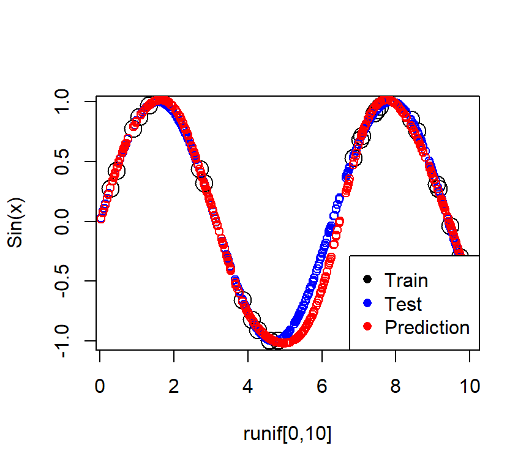

Training data, test data and predictions

```r
plot(tr_data, cex = 2, xlab = "runif[0,10]", ylab = "Sin(x)")
points(te_data, col = "blue", cex = 1)
points(te_data[,1], predictions, col = "red", cex = 1)
legend("bottomright", legend = c("Train", "Test", "Prediction"),
col = c("black", "blue", "red"), pch = 16)
```

The neural network have successfully learned the sin(x) pattern as the test plot and prediction plot follows each other very well.

## 3.2

In question (1), you used the default logistic (a.k.a. sigmoid) activation function, i.e. act.fct = “logistic”. Repeat question (1) with the following custom activation functions: $h_1(x) = x, h_2(x) = max{0, x}$ and $h_3(x) = \text{ln}(1 + exp x)$ (a.k.a. linear, ReLU and softplus). See the help file of the neuralnet package to learn how to use custom activation functions. Plot and comment your results.

```r
# Three custom activation function
h1 <- function(x) x
h2 <- function(x) ifelse(x > 0, x, 0) # same as max(0,x)
h3 <- function(x) log(1 + exp(x))


# Neural Network
nn_model_h1 <- neuralnet(sin ~ runif, data = tr_data, hidden = c(10), act.fct = h1, startweights = winit)
nn_model_h2 <- neuralnet(sin ~ runif, data = tr_data, hidden = c(10), act.fct = h2, startweights = winit)
nn_model_h3 <- neuralnet(sin ~ runif, data = tr_data, hidden = c(10), act.fct = h3, startweights = winit)

predictions_h1 <- predict(nn_model_h1, newdata = te_data) %>% as.vector()
predictions_h2 <- predict(nn_model_h2, newdata = te_data) %>% as.vector()
predictions_h3 <- predict(nn_model_h3, newdata = te_data) %>% as.vector()
```

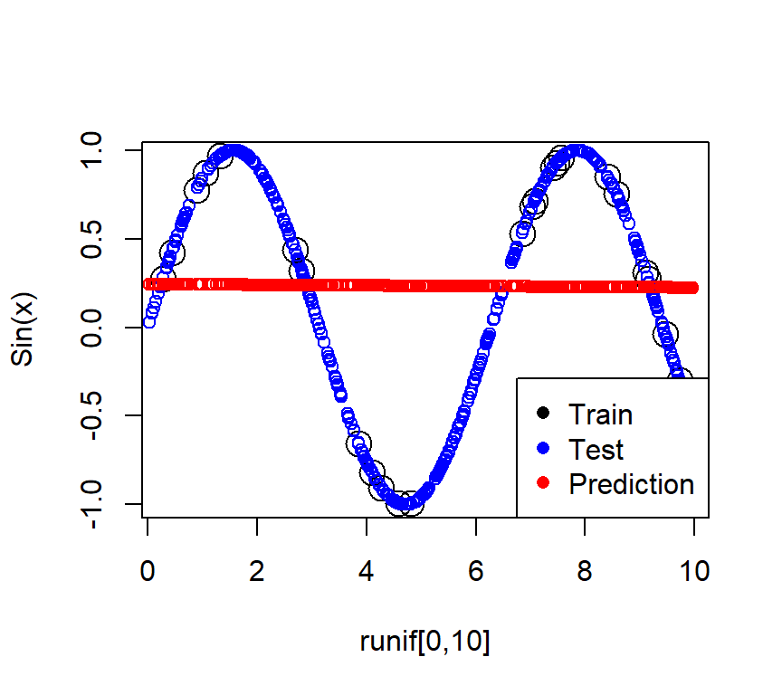

Training data, test data and predictions for first activation function (linear)

```r
plot(tr_data, cex = 2, xlab = "runif[0,10]", ylab = "Sin(x)")
points(te_data, col = "blue", cex=1)
points(te_data[,1], predictions_h1, col = "red", cex = 1)
legend("bottomright", legend = c("Train", "Test", "Prediction"),
col = c("black", "blue", "red"), pch = 16)
```

In figure 2, we can see that the prediction is just a straight line and does not not fit the test data well. This is because the linear activation function can only represent linear mappings between input and output. Therefore, the prediction does not fit the test data well because the data is non-linear.

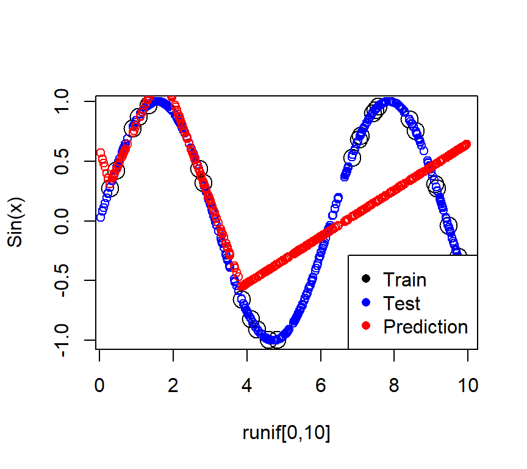

Training data, test data and predictions for second activation function (ReLu)

```r
plot(tr_data, cex = 2, xlab = "runif[0,10]", ylab = "Sin(x)")
points(te_data, col = "blue", cex = 1)
points(te_data[,1], predictions_h2, col = "red", cex = 1)
legend("bottomright", legend = c("Train", "Test", "Prediction"),
col = c("black", "blue", "red"), pch = 16)
```

In figure 3, when we use ReLu as a activation function we get better result than the linear activation function, but still this is very bad fit to the test data.

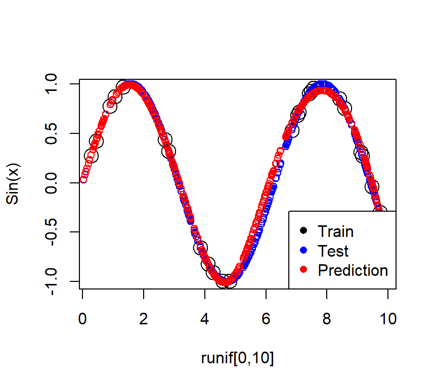

Training data, test data and predictions for third activation function

```r
plot(tr_data, cex = 2, xlab = "runif[0,10]", ylab = "Sin(x)")
points(te_data, col = "blue", cex=1)
points(te_data[,1], predictions_h3, col = "red", cex = 1)
legend("bottomright", legend = c("Train", "Test", "Prediction"),
col = c("black", "blue", "red"), pch = 16)
```

## 3.3

Sample 500 points uniformly at random in the interval [0, 50], and apply the sine function to each point. Use the NN learned in question (1) to predict the sine function value for these new 500 points. You should get mixed results. Plot and comment your results.

```r
# The data
set.seed(1234567890)
data_runif <- runif(500, min = 0, max = 50)
data_df <- data.frame(runif = data_runif, sin =  sin(data_runif))





predictions <- predict(nn_model_assignment_1, newdata = data_df) %>% as.vector()
```

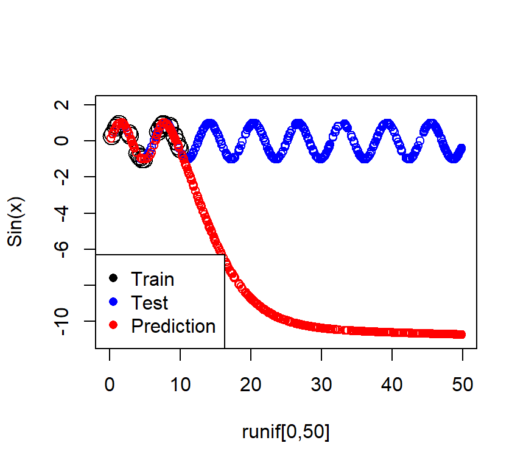

Training data, test data and predictions with runif[0,50]

```r
plot(tr_data, cex = 2, xlab = "runif[0,50]", ylab = "Sin(x)", ylim = c(-11, 2), xlim = c(0,50))
points(data_df, col = "blue", cex=1)
points(data_df[,1], predictions, col = "red", cex=1)
legend("bottomleft", legend = c("Train", "Test", "Prediction"),
col = c("black", "blue", "red"), pch = 16)
```

In figure 5, the predictions follows the test data well between values from 0 to 10. This makes sense, because the NN learned in question (1) trained values between 0 to 10.

## 3.4

In question (3), the predictions seem to converge to some value. Explain why this happens. To answer this question, you may need to get access to the weights of the NN learned. You can do it by running *nn* or *nn*$*weights* where *nn* is the NN learned.

**Answer:** To understand why the predictions seem to converge to some value we need to look at the formula for the full NN model (Lindholm et al., 2022).

$$\mathbf{q} =
h(\mathbf{W}^{(1)}\mathbf{x}+ \mathbf{b}^{1})$$
$$\hat{y} =\mathbf{W}^{(2)}\mathbf{q}+
\mathbf{b}^{2}$$

- $h$ is the activation function $h(z) = \frac{1}{1+e^{-z}}$
- $\mathbf{W}$ is the weight matrix.
- $\mathbf{x}$ is the input.
- $\mathbf{b}$ is the bias.
- $\hat{y}$ is the prediction.

In the table below we print out the weights and bias from the NN.

```r
W1 <- nn_model_assignment_1$weights[[1]][[1]][2,]
b1 <- nn_model_assignment_1$weights[[1]][[1]][1,]

W2 <- nn_model_assignment_1$weights[[1]][[2]][2:11,]
b2 <- nn_model_assignment_1$weights[[1]][[2]][1,]

mat <- matrix("", 10, 4)
colnames(mat) <- c("W1", "W2", "b1", "b2")

mat[1:10,1] <- round(W1,2)
mat[1:10,2] <- round(W2,2)
mat[1:10,3] <- round(b1,2)
mat[1,4] <-round(b2,2)

kable(mat, caption = "The weights and the bias")
```

The weights and the bias

| W1 | W2 | b1 | b2 |
| --- | --- | --- | --- |
| 4.04 | 0.77 | -11.87 | -0.11 |
| -0.54 | -1.04 | -0.92 |  |
| 0.26 | -16.05 | -3.03 |  |
| -0.55 | -1.27 | 1.53 |  |
| -2.23 | 3.28 | 6.56 |  |
| 1.79 | 4.31 | -11.77 |  |
| -1.26 | 0.12 | 1.4 |  |
| -2.2 | -1.22 | 0.2 |  |
| -0.59 | -2.76 | 0.29 |  |
| -0.03 | 2.37 | -0.21 |  |

Now we calculate $\mathbf{q}$ by using $\mathbf{W}^{(1)}$, $\mathbf{x}$ (some high number, we use 50) and $\mathbf{b}^{1}$.

```r
# Activation function
logistic <- function(x){
  out <- 1 / (1 + exp(-x))
 return(out)
}

# Input (some high value)
x <- 50
q <- logistic(W1 * x + b1)

kable(q, digits = 0, col.names = "q")
```

| q |
| --- |
| 1 |
| 0 |
| 1 |
| 0 |
| 0 |
| 1 |
| 0 |
| 0 |
| 0 |
| 0 |

```r
# W2 %*% q + b2
```

We know that the logistic function are going to return 1 if the input is large and 0 if the input is small and that is why the $\mathbf{q}$ are going to have the same output if we have a large value for $x$. This is because all positive weights from $\mathbf{W}^{(1)}$ become large, and negative weights become small as $x$ increases.

## 3.5

Sample 500 points uniformly at random in the interval [0, 10], and apply the sine func-tion to each point. Use all these points as training points for learning a NN that tries to predict $x$ from $sin(x)$, i.e. unlike before when the goal was to predict $sin(x)$ from $x$. Use the learned NN to predict the training data. You should get bad results. Plot and comment your results. Help: Some people get a convergence error in this question. It can be solved by stopping the training before reaching convergence by setting threshold = 0.1.

```r
set.seed(1234567890)
data_runif <- runif(500, min = 0, max = 10)
data_df <- data.frame(runif = data_runif, sin = sin(data_runif))

tr_data <- data_df[1:25,]
te_data <-  data_df[26:500,]

# Random initialization of the weights in the interval [-1, 1], 20 weights + 11 bias
winit <- runif(31, min = -1, max = 1)
```

```r
# Neural Network
nn_model <- neuralnet(runif ~ sin, data = tr_data, hidden = c(10), startweights = winit,
                      threshold = 0.1)

predictions <- predict(nn_model, newdata = te_data) %>% as.vector()
```

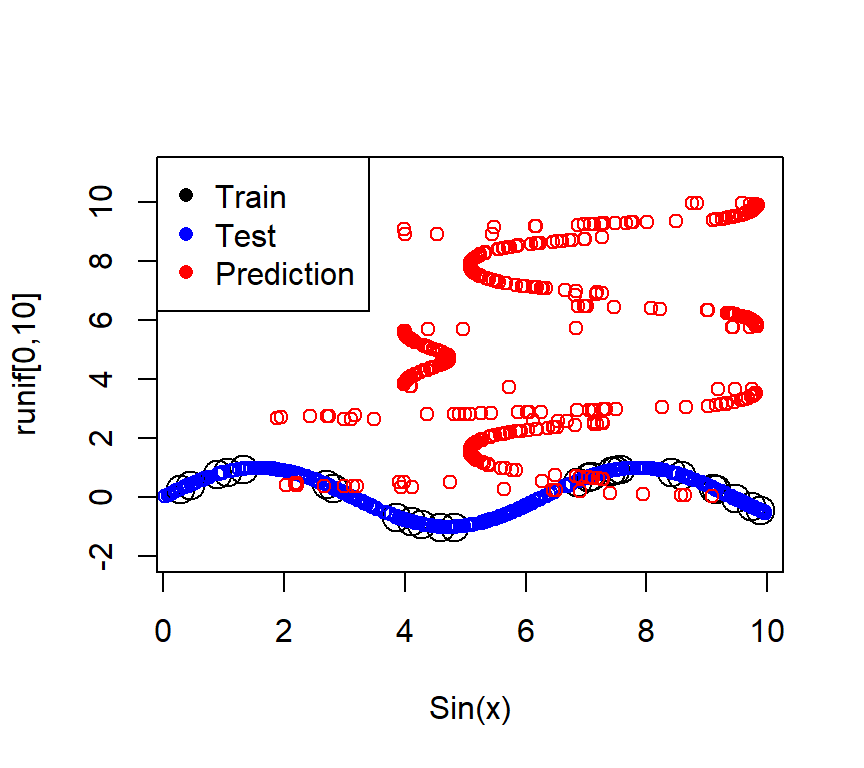

Training data, test data and predictions, x ~ sin(x)

```r
plot(tr_data, cex = 2, ylab = "runif[0,10]", xlab = "Sin(x)", ylim = c(-2, 11))
points(te_data, col = "blue", cex = 1)
points(predictions, te_data[,1], col = "red", cex = 1)
legend("topleft", legend = c("Train", "Test", "Prediction"),
col = c("black", "blue", "red"), pch = 16)
```

In figure 6, we can see that the predicted values does not fit the a test data at all. This is because the $sin(x)$ function can return same value for different $x$ values and therefore the NN gets confused.